# Acquiring the data

```python
# Running first cell for *weekly* "Search Trends" dataset collection, cleaning, and partial display

import pandas as pd
url = 'https://raw.githubusercontent.com/google-research/open-covid-19-data/master/data/exports/search_trends_symptoms_dataset/United%20States%20of%20America/2020_US_weekly_symptoms_dataset.csv'
df1 = pd.read_csv(url,index_col=0,parse_dates=[0])
# Find the columns where every value is null
empty_cols = [col for col in df1.columns if df1[col].isnull().all()]
# Drop these columns from the dataframe
df1.drop(empty_cols,
        axis=1,
        inplace=True)
df1['state_codes']=df1.index.str[3:]
#drop 'sub_region_1_code' column bc redundant
redundant = ['sub_region_1_code']
df1=df1.drop(columns=redundant)
# Delete rows which contains less than 30 non NaN values
#df1=df1.dropna(thresh=30)
df1['date']= pd.to_datetime(df1['date'])
#create multi-index constructed from date and open_covid_region_code
df1 = df1.set_index([df1.index,'date'])
print (df1.head(5))
print (df1.shape)
```

```
                                  country_region_code country_region  \
open_covid_region_code date
US-AK                  2020-01-06                  US  United States
                       2020-01-13                  US  United States
                       2020-01-20                  US  United States
                       2020-01-27                  US  United States
                       2020-02-03                  US  United States

                                  sub_region_1  symptom:Adrenal crisis  \
open_covid_region_code date
US-AK                  2020-01-06       Alaska                   12.69
                       2020-01-13       Alaska                    9.56
                       2020-01-20       Alaska                     NaN
                       2020-01-27       Alaska                   15.31
                       2020-02-03       Alaska                    8.81

                                   symptom:Ageusia  \
open_covid_region_code date
US-AK                  2020-01-06              NaN
                       2020-01-13              NaN
                       2020-01-20              NaN
                       2020-01-27             7.47
                       2020-02-03              NaN

                                   symptom:Allergic conjunctivitis  \
open_covid_region_code date
US-AK                  2020-01-06                              NaN
                       2020-01-13                              NaN
                       2020-01-20                              NaN
                       2020-01-27                              NaN
                       2020-02-03                              NaN

                                   symptom:Amblyopia  symptom:Amenorrhea  \
open_covid_region_code date
US-AK                  2020-01-06                NaN               12.29
                       2020-01-13                NaN               12.62
                       2020-01-20                NaN               14.17
                       2020-01-27                NaN               15.67
                       2020-02-03                NaN               13.87

```

[output cut: 67 more lines]

```
                       2020-01-13                      NaN         16.26
                       2020-01-20                      NaN         17.48
                       2020-01-27                      NaN         10.93
                       2020-02-03                     10.5         18.93

                                   state_codes
open_covid_region_code date
US-AK                  2020-01-06           AK
                       2020-01-13           AK
                       2020-01-20           AK
                       2020-01-27           AK
                       2020-02-03           AK

[5 rows x 125 columns]
(624, 125)
```

```python
# Running second cell for the *daily* "Search Trends" dataset collection, cleaning, and partial display
import pandas as pd
url = 'https://raw.githubusercontent.com/google-research/open-covid-19-data/master/data/exports/search_trends_symptoms_dataset/United%20States%20of%20America/2020_US_daily_symptoms_dataset.csv'
df_daily = pd.read_csv(url,index_col=0,parse_dates=[0])
# Find the columns where every value is null
empty_cols = [col for col in df_daily.columns if df_daily[col].isnull().all()]
# Drop these columns from the dataframe
df_daily.drop(empty_cols,
        axis=1,
        inplace=True)
df_daily['state_codes']=df_daily.index.str[3:]
#drop 'sub_region_1_code' column bc redundant
redundant = ['sub_region_1_code']
df_daily=df_daily.drop(columns=redundant)
# Delete rows which contains less than 350 non NaN values
df_daily=df_daily.dropna(thresh=390)
#convert date format and resample to weekly
df_daily['date'] = pd.to_datetime(df_daily['date'])
df_daily=df_daily.set_index('date').groupby([df_daily.index, 'state_codes']).resample('W', label='left', loffset=pd.DateOffset(days=1)).sum().fillna(0).reset_index().set_index('open_covid_region_code')
#create multi-index constructed from date and open_covid_region_code
df_daily = df_daily.set_index([df_daily.index,'date'])
#print (df_daily.head(5))
print (df_daily.shape)
```

```
(1431, 423)
```

```python
# Running third cell for "COVID Hospitalization Cases" dataset collection, cleaning, and partial display

import numpy as np
pd.set_option('display.max_rows', None)
pd.set_option('display.max_columns', None)
pd.set_option('display.width', None)
pd.set_option('display.max_colwidth', -1)
url = 'https://raw.githubusercontent.com/google-research/open-covid-19-data/master/data/exports/cc_by/aggregated_cc_by.csv'
df2 = pd.read_csv(url,index_col=0,parse_dates=[0])
#replace 0 values with null
df2 = df2.replace({0.0:np.nan})
#get rid of irrelevant features
relevant_col = ['region_name', 'date', 'hospitalized_new']
df2=df2[relevant_col]
# Delete rows which have no value for hospitalized_new
df2=df2.dropna(subset = ['hospitalized_new'])
#convert date format and resample to weekly
df2['date'] = pd.to_datetime(df2['date'])
df2=df2.set_index('date').groupby([df2.index, 'region_name']).resample('W', label='left', loffset=pd.DateOffset(days=1)).sum().fillna(0).reset_index().set_index('open_covid_region_code')
#create multi-index constructed from open_covid_region_code and 'date'
df2 = df2.set_index([df2.index, 'date'])
print (df2.head(10))
print (df2.shape)
```

```
                                   region_name  hospitalized_new
open_covid_region_code date
CHE                    2020-02-24  Switzerland  49.0
                       2020-03-02  Switzerland  106.0
                       2020-03-09  Switzerland  339.0
                       2020-03-16  Switzerland  819.0
                       2020-03-23  Switzerland  1147.0
                       2020-03-30  Switzerland  630.0
                       2020-04-06  Switzerland  340.0
                       2020-04-13  Switzerland  212.0
                       2020-04-20  Switzerland  97.0
                       2020-04-27  Switzerland  59.0
(4483, 2)
```

```python
# Running fourth cell for merging the weekly symptoms and hospitalization datasets. One dataframe object for visualization and one for machine learning algorithms.
# Both dataframes objects are shown partially.

pd.set_option('display.max_rows', None)
pd.set_option('display.max_columns', None)
pd.set_option('display.width', None)
pd.set_option('display.max_colwidth', -1)
inner_df = pd.merge(df1, df2, left_index=True, right_index=True)
#inner_df contains only points that have data for both symptoms and hospitalizations
left_df = pd.merge(df1, df2, left_index=True, right_index=True, how='left')
#left_df contains all rows in df1, even if hospitalized_new value is null
print (left_df.head(5))
print(left_df.shape)
print (inner_df.head(5))
print (inner_df.shape)
```

```
                                  country_region_code country_region  \
open_covid_region_code date
US-AK                  2020-01-06  US                  United States
                       2020-01-13  US                  United States
                       2020-01-20  US                  United States
                       2020-01-27  US                  United States
                       2020-02-03  US                  United States

                                  sub_region_1  symptom:Adrenal crisis  \
open_covid_region_code date
US-AK                  2020-01-06  Alaska       12.69
                       2020-01-13  Alaska       9.56
                       2020-01-20  Alaska      NaN
                       2020-01-27  Alaska       15.31
                       2020-02-03  Alaska       8.81

                                   symptom:Ageusia  \
open_covid_region_code date
US-AK                  2020-01-06 NaN
                       2020-01-13 NaN
                       2020-01-20 NaN
                       2020-01-27  7.47
                       2020-02-03 NaN

                                   symptom:Allergic conjunctivitis  \
open_covid_region_code date
US-AK                  2020-01-06 NaN
                       2020-01-13 NaN
                       2020-01-20 NaN
                       2020-01-27 NaN
                       2020-02-03 NaN

                                   symptom:Amblyopia  symptom:Amenorrhea  \
open_covid_region_code date
US-AK                  2020-01-06 NaN                 12.29
                       2020-01-13 NaN                 12.62
                       2020-01-20 NaN                 14.17
                       2020-01-27 NaN                 15.67
                       2020-02-03 NaN                 13.87

```

[output cut: 1369 more lines]

```
open_covid_region_code date
US-AK                  2020-03-23  13.79                    15.69
                       2020-03-30  8.82                     17.63
                       2020-04-06  9.07                     14.12
                       2020-04-13 NaN                       18.01
                       2020-04-20 NaN                       16.11

                                  state_codes region_name  hospitalized_new
open_covid_region_code date
US-AK                  2020-03-23  AK          Alaska      6.0
                       2020-03-30  AK          Alaska      14.0
                       2020-04-06  AK          Alaska      11.0
                       2020-04-13  AK          Alaska      5.0
                       2020-04-20  AK          Alaska     -36.0
(310, 127)
```

```python
# Running fifth cell for merging the daily symptoms and hospitalization datasets. One dataframe object for visualization and one for machine learning algorithms.
# Both dataframes objects are shown partially.
pd.set_option('display.max_rows', None)
pd.set_option('display.max_columns', None)
pd.set_option('display.width', None)
pd.set_option('display.max_colwidth', -1)

#inner_df2 contains only points that have data for both symptoms and hospitalizations
inner_df2 = pd.merge(df_daily, df2, left_index=True, right_index=True)

#left_df2 contains all rows in df_daily, even if hospitalized_new value is null
left_df2 = pd.merge(df_daily, df2, left_index=True, right_index=True, how='left')

print (left_df2.head(5))
print(left_df2.shape)
print (inner_df2.head(5))
print (inner_df2.shape)
left_df2.to_csv('out2.csv')
```

```
                                  state_codes  symptom:Abdominal obesity  \
open_covid_region_code date
US-AL                  2019-12-30  AL          13.29
                       2020-01-06  AL          17.97
                       2020-01-13  AL          18.40
                       2020-01-20  AL          17.88
                       2020-01-27  AL          17.06

                                   symptom:Abdominal pain  symptom:Acne  \
open_covid_region_code date
US-AL                  2019-12-30  25.75                   45.98
                       2020-01-06  33.66                   59.62
                       2020-01-13  33.72                   58.41
                       2020-01-20  33.87                   61.95
                       2020-01-27  33.48                   56.98

                                   symptom:Actinic keratosis  \
open_covid_region_code date
US-AL                  2019-12-30  1.71
                       2020-01-06  2.41
                       2020-01-13  2.46
                       2020-01-20  2.74
                       2020-01-27  2.72

                                   symptom:Acute bronchitis  \
open_covid_region_code date
US-AL                  2019-12-30  4.36
                       2020-01-06  5.12
                       2020-01-13  4.55
                       2020-01-20  4.50
                       2020-01-27  5.25

                                   symptom:Adrenal crisis  symptom:Ageusia  \
open_covid_region_code date
US-AL                  2019-12-30  0.57                    0.14
                       2020-01-06  0.80                    0.14
                       2020-01-13  0.86                    0.23
                       2020-01-20  0.96                    0.37
                       2020-01-27  0.85                    0.14

```

[output cut: 4649 more lines]

```
open_covid_region_code date
US-AL                  2020-03-30  2.21                  Alabama
                       2020-04-06  2.18                  Alabama
                       2020-04-13  2.41                  Alabama
                       2020-04-20  2.59                  Alabama
                       2020-04-27  2.59                  Alabama

                                   hospitalized_new
open_covid_region_code date
US-AL                  2020-03-30  231.0
                       2020-04-06  206.0
                       2020-04-13  204.0
                       2020-04-20  204.0
                       2020-04-27  190.0
(699, 425)
```

**Part 2: Visualization**

First, we visualize the data from the weekly symptoms dataset, which did not provide great results in comparison to the daily symptoms dataset

```python
#visualization of weekly dataset
import plotly.express as px
import plotly.graph_objects as go
import pandas as pd
df = pd.read_csv('out.csv')
df=df.dropna(axis=1, thresh=100)
#keep only sympoms with highest mean search frequency
means = df.mean()
most_pop = [ind for m,ind in zip(means,means.index) if m>17]
state_codes = df['state_codes']
date = df['date']
open_covid_region_code = df['open_covid_region_code']
df = df[most_pop]
df['state_codes']= state_codes
df['open_covid_region_code'] = open_covid_region_code
df['date'] = date
df['date_by_week'] = date
df = df.set_index(['open_covid_region_code', 'date'])
fig = px.choropleth(df, locations=df['state_codes'],
                    color=df['symptom:Developmental disability'],
                    hover_name=df['symptom:Developmental disability'],
                    locationmode = 'USA-states',
                    animation_frame=df['date_by_week'],
                    title = "Symptom Google Search Frequency in USA",
                    scope = "usa",
                    color_continuous_scale=px.colors.sequential.PuRd)
fig["layout"].pop("updatemenus")

fig = px.choropleth(df, locations=df['state_codes'],
                    color=df['symptom:Photodermatitis'],
                    hover_name=df['symptom:Photodermatitis'],
                    locationmode = 'USA-states',
                    animation_frame=df['date_by_week'],
                    title = "'Photodermatitis' Google Search Frequency in USA",
                    scope = "usa",
                   color_continuous_scale=px.colors.sequential.PuRd)
fig["layout"].pop("updatemenus")

fig2 = px.choropleth(df, locations=df['state_codes'],
                    color=df['symptom:Croup'],
                    hover_name=df['symptom:Croup'],
                    locationmode = 'USA-states',
                    animation_frame=df['date_by_week'],
                    title = "'Croup' Google Search Frequency in USA",
                    scope = "usa",
                   color_continuous_scale=px.colors.sequential.PuRd)
fig2["layout"].pop("updatemenus")

fig3 = px.choropleth(df, locations=df['state_codes'],
                    color=df['symptom:Developmental disability'],
                    hover_name=df['symptom:Developmental disability'],
                    locationmode = 'USA-states',
                    animation_frame=df['date_by_week'],
                    title = "'Developmental Disability' Google Search Frequency in USA",
                    scope = "usa",
                   color_continuous_scale=px.colors.sequential.PuRd)
fig3["layout"].pop("updatemenus")


fig.show()
fig2.show()
fig3.show()
```

[interactive chart not shown]

```python
#visualization of weekly dataset
import plotly.express as px
import plotly.graph_objects as go
import pandas as pd
df = pd.read_csv('out2.csv')
#keep only sympoms with highest mean search frequency
means = df.mean()
most_pop = [ind for m,ind in zip(means,means.index) if m>60]
state_codes = df['state_codes']
date = df['date']
open_covid_region_code = df['open_covid_region_code']
df = df[most_pop]
df['state_codes']= state_codes
df['open_covid_region_code'] = open_covid_region_code
df['date'] = date
df['date_by_week'] = date
df = df.set_index(['open_covid_region_code', 'date'])

fig = px.choropleth(df, locations=df['state_codes'],
                    color=df['symptom:Allergy'],
                    hover_name=df['symptom:Allergy'],
                    locationmode = 'USA-states',
                    animation_frame=df['date_by_week'],
                    title = "'Allergy' Google Search Frequency in USA",
                    scope = "usa",
                   color_continuous_scale=px.colors.sequential.PuRd)
fig["layout"].pop("updatemenus")

fig2 = px.choropleth(df, locations=df['state_codes'],
                    color=df['symptom:Common cold'],
                    hover_name=df['symptom:Common cold'],
                    locationmode = 'USA-states',
                    animation_frame=df['date_by_week'],
                    title = "'Common Cold' Google Search Frequency in USA",
                    scope = "usa",
                   color_continuous_scale=px.colors.sequential.PuRd)
fig2["layout"].pop("updatemenus")

fig3 = px.choropleth(df, locations=df['state_codes'],
                    color=df['symptom:Infection'],
                    hover_name=df['symptom:Infection'],
                    locationmode = 'USA-states',
                    animation_frame=df['date_by_week'],
                    title = "'Infection' Google Search Frequency in USA",
                    scope = "usa",
                   color_continuous_scale=px.colors.sequential.PuRd)
fig3["layout"].pop("updatemenus")

fig4 = px.choropleth(df, locations=df['state_codes'],
                    color=df['symptom:Pain'],
                    hover_name=df['symptom:Pain'],
                    locationmode = 'USA-states',
                    animation_frame=df['date_by_week'],
                    title = "'Pain' Google Search Frequency in USA",
                    scope = "usa",
                   color_continuous_scale=px.colors.sequential.PuRd)
fig4["layout"].pop("updatemenus")
fig.show()
fig2.show()
fig3.show()
fig4.show()
```

[interactive chart not shown]

# Processing the data

```python
import seaborn as sns
import matplotlib.pyplot as plt
%matplotlib inline
left_df.describe()
left_df.head()
```

| open_covid_region_code | date | country_region_code | country_region | sub_region_1 | symptom:Adrenal crisis | symptom:Ageusia | symptom:Allergic conjunctivitis | symptom:Amblyopia | symptom:Amenorrhea | symptom:Angular cheilitis | symptom:Anosmia | symptom:Aphonia | symptom:Ascites | symptom:Asphyxia | symptom:Atheroma | symptom:Auditory hallucination | symptom:Balance disorder | symptom:Beau's lines | symptom:Bleeding on probing | symptom:Burning Chest Pain | symptom:Burning mouth syndrome | symptom:Cataplexy | symptom:Chancre | symptom:Chorea | symptom:Cleft lip and cleft palate | symptom:Clouding of consciousness | symptom:Compulsive hoarding | symptom:Crackles | symptom:Crepitus | … |
| --- | --- | --- | --- | --- | --- | --- | --- | --- | --- | --- | --- | --- | --- | --- | --- | --- | --- | --- | --- | --- | --- | --- | --- | --- | --- | --- | --- | --- | --- | --- |
| US-AK | 2020-01-06 | US | United States | Alaska | 12.69 | NaN | NaN | NaN | 12.29 | NaN | NaN | NaN | NaN | 10.31 | 11.10 | 8.92 | 11.10 | 7.93 | 11.90 | NaN | 12.10 | 12.29 | 28.36 | 12.10 | 18.05 | NaN | NaN | 8.33 | 12.49 | … |
|  | 2020-01-13 | US | United States | Alaska | 9.56 | NaN | NaN | NaN | 12.62 | NaN | NaN | NaN | NaN | 13.20 | 13.20 | 8.61 | 10.90 | 11.86 | 9.56 | NaN | 10.33 | 14.92 | 20.27 | 11.47 | 34.81 | 9.95 | NaN | 8.22 | NaN | … |
|  | 2020-01-20 | US | United States | Alaska | NaN | NaN | NaN | NaN | 14.17 | NaN | 7.36 | NaN | NaN | 14.90 | 10.49 | 8.28 | 11.78 | 11.96 | 17.66 | NaN | 11.22 | 11.04 | 18.03 | 11.59 | 19.14 | 8.83 | NaN | 8.28 | 10.49 | … |
|  | 2020-01-27 | US | United States | Alaska | 15.31 | 7.47 | NaN | NaN | 15.67 | 7.47 | NaN | 7.65 | NaN | 12.03 | 11.84 | 13.12 | NaN | 12.03 | 9.11 | NaN | 9.47 | 13.85 | 23.87 | 12.94 | 15.49 | 9.84 | NaN | 10.39 | 12.39 | … |
|  | 2020-02-03 | US | United States | Alaska | 8.81 | NaN | NaN | NaN | 13.87 | 8.06 | NaN | 12.56 | NaN | 14.24 | 9.75 | 8.81 | 13.12 | NaN | 9.00 | 7.5 | 14.62 | 14.24 | 21.55 | 15.37 | 13.12 | NaN | NaN | 10.31 | 9.93 | … |

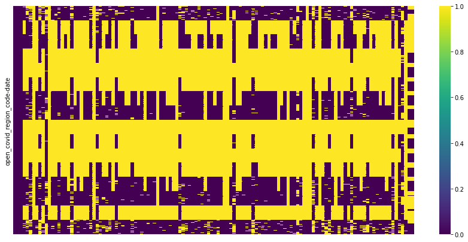

```python
plt.figure(figsize = (15,7))
sns.heatmap(data = left_df.isnull(),xticklabels = False, yticklabels = False, cmap = 'viridis')
```

```python
inner_df.head(5)
```

| open_covid_region_code | date | country_region_code | country_region | sub_region_1 | symptom:Adrenal crisis | symptom:Ageusia | symptom:Allergic conjunctivitis | symptom:Amblyopia | symptom:Amenorrhea | symptom:Angular cheilitis | symptom:Anosmia | symptom:Aphonia | symptom:Ascites | symptom:Asphyxia | symptom:Atheroma | symptom:Auditory hallucination | symptom:Balance disorder | symptom:Beau's lines | symptom:Bleeding on probing | symptom:Burning Chest Pain | symptom:Burning mouth syndrome | symptom:Cataplexy | symptom:Chancre | symptom:Chorea | symptom:Cleft lip and cleft palate | symptom:Clouding of consciousness | symptom:Compulsive hoarding | symptom:Crackles | symptom:Crepitus | … |
| --- | --- | --- | --- | --- | --- | --- | --- | --- | --- | --- | --- | --- | --- | --- | --- | --- | --- | --- | --- | --- | --- | --- | --- | --- | --- | --- | --- | --- | --- | --- |
| US-AK | 2020-03-23 | US | United States | Alaska | 11.15 | 16.57 | NaN | NaN | 9.53 | NaN | 45.17 | NaN | NaN | 9.39 | 11.44 | 6.45 | 9.97 | 11.15 | 9.68 | 14.08 | 8.65 | 11.44 | 14.67 | 15.99 | 10.85 | NaN | NaN | 8.36 | NaN | … |
|  | 2020-03-30 | US | United States | Alaska | 8.96 | 8.96 | 7.11 | NaN | 8.53 | NaN | 19.05 | NaN | NaN | 11.94 | 7.54 | 6.54 | 10.95 | 12.51 | 8.11 | 8.53 | 10.24 | 12.37 | 17.35 | 11.66 | 9.95 | 6.68 | NaN | NaN | NaN | … |
|  | 2020-04-06 | US | United States | Alaska | 10.08 | 7.35 | NaN | NaN | 10.80 | 7.06 | 6.77 | NaN | NaN | 9.65 | 11.52 | NaN | 10.80 | 9.65 | 13.11 | 7.20 | 9.22 | NaN | 13.83 | 15.85 | 10.08 | NaN | NaN | 7.20 | NaN | … |
|  | 2020-04-13 | US | United States | Alaska | 6.24 | NaN | NaN | NaN | 7.94 | 6.52 | 10.64 | NaN | NaN | 10.50 | 8.65 | 9.50 | 8.79 | 11.77 | 9.22 | 7.80 | 11.21 | 9.64 | 16.74 | 10.78 | 9.36 | 8.94 | NaN | 7.23 | 7.94 | … |
|  | 2020-04-20 | US | United States | Alaska | 7.40 | NaN | 6.24 | NaN | 11.90 | NaN | NaN | NaN | NaN | 9.14 | 13.06 | 9.87 | 11.90 | 10.89 | 9.58 | 7.69 | 9.87 | 7.69 | 12.63 | 8.71 | 13.06 | 5.95 | NaN | 6.39 | 11.03 | … |

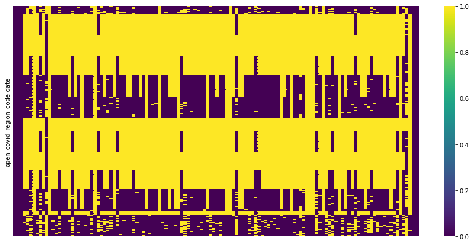

```python
plt.figure(figsize = (15,7))
sns.heatmap(data = inner_df.isnull(),xticklabels = False, yticklabels = False, cmap = 'viridis')

# The takeaway is that when we take data only corresponding to the regions AND specific weeks for hospitalization cases, there
# are less NA values (less yellow)
```

It can be seen that even in inner_df, there are MANY NA values. For proper machine learning algorithms, it is important that this dataframe must be mostly complete.

So, we apply PCA to reduce the number of features.

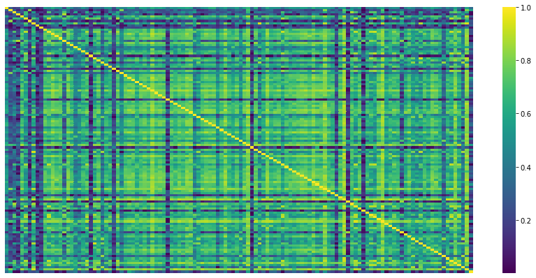

```python
plt.figure(figsize=(15,7))
#sns.heatmap(df1.corr().abs(),xticklabels = False, yticklabels = False, cmap = 'viridis')
sns.heatmap(left_df.corr().abs(),xticklabels = False, yticklabels = False, cmap = 'viridis')
```

```python
# Now we will drop region_name (redundant), country_region_code, sub_region_1, and country_region
left_df.drop(['country_region_code','country_region','sub_region_1','region_name'],axis=1,inplace=True)
```

```
(624, 122)
```

| open_covid_region_code | date | symptom:Adrenal crisis | symptom:Ageusia | symptom:Allergic conjunctivitis | symptom:Amblyopia | symptom:Amenorrhea | symptom:Angular cheilitis | symptom:Anosmia | symptom:Aphonia | symptom:Ascites | symptom:Asphyxia | symptom:Atheroma | symptom:Auditory hallucination | symptom:Balance disorder | symptom:Beau's lines | symptom:Bleeding on probing | symptom:Burning Chest Pain | symptom:Burning mouth syndrome | symptom:Cataplexy | symptom:Chancre | symptom:Chorea | symptom:Cleft lip and cleft palate | symptom:Clouding of consciousness | symptom:Compulsive hoarding | symptom:Crackles | symptom:Crepitus | symptom:Croup | symptom:Cyanosis | symptom:Depersonalization | … |
| --- | --- | --- | --- | --- | --- | --- | --- | --- | --- | --- | --- | --- | --- | --- | --- | --- | --- | --- | --- | --- | --- | --- | --- | --- | --- | --- | --- | --- | --- | --- |
| US-AK | 2020-01-06 | 12.69 | NaN | NaN | NaN | 12.29 | NaN | NaN | NaN | NaN | 10.31 | 11.10 | 8.92 | 11.10 | 7.93 | 11.90 | NaN | 12.10 | 12.29 | 28.36 | 12.10 | 18.05 | NaN | NaN | 8.33 | 12.49 | 25.78 | 10.51 | 12.10 | … |
|  | 2020-01-13 | 9.56 | NaN | NaN | NaN | 12.62 | NaN | NaN | NaN | NaN | 13.20 | 13.20 | 8.61 | 10.90 | 11.86 | 9.56 | NaN | 10.33 | 14.92 | 20.27 | 11.47 | 34.81 | 9.95 | NaN | 8.22 | NaN | 25.05 | 11.86 | 7.65 | … |
|  | 2020-01-20 | NaN | NaN | NaN | NaN | 14.17 | NaN | 7.36 | NaN | NaN | 14.90 | 10.49 | 8.28 | 11.78 | 11.96 | 17.66 | NaN | 11.22 | 11.04 | 18.03 | 11.59 | 19.14 | 8.83 | NaN | 8.28 | 10.49 | 29.99 | 7.73 | NaN | … |
|  | 2020-01-27 | 15.31 | 7.47 | NaN | NaN | 15.67 | 7.47 | NaN | 7.65 | NaN | 12.03 | 11.84 | 13.12 | NaN | 12.03 | 9.11 | NaN | 9.47 | 13.85 | 23.87 | 12.94 | 15.49 | 9.84 | NaN | 10.39 | 12.39 | 29.52 | 9.84 | 8.20 | … |
|  | 2020-02-03 | 8.81 | NaN | NaN | NaN | 13.87 | 8.06 | NaN | 12.56 | NaN | 14.24 | 9.75 | 8.81 | 13.12 | NaN | 9.00 | 7.5 | 14.62 | 14.24 | 21.55 | 15.37 | 13.12 | NaN | NaN | 10.31 | 9.93 | 39.36 | 10.87 | 9.37 | … |

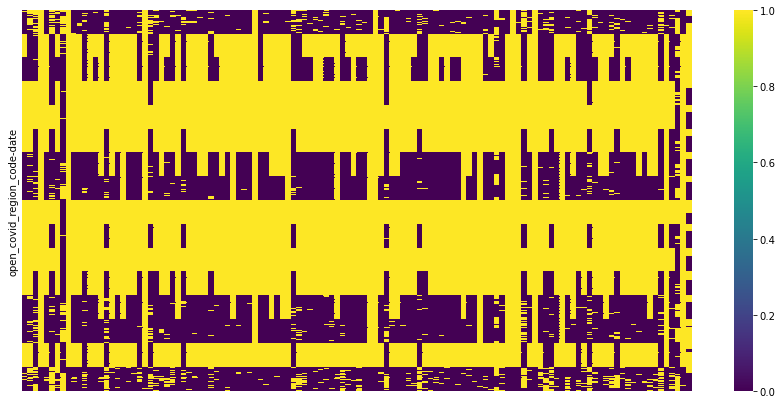

```python
plt.figure(figsize=(15,7))
sns.heatmap(data = left_df.isnull(),xticklabels = False, yticklabels = False, cmap = 'viridis')
print(left_df.shape)
left_df.head()
```

```python
# Now to apply PCA, we need to a "full" dataframe. We either need to remove NA values or fill them in.
# With rows/samples missing atleast 50% of its data, they are straight away removed.

left_df = left_df[left_df.isnull().mean(axis=1)<0.50]

# Removed 390 samples from 624 to 234
left_df.shape
```

```
(234, 122)
```

```python
left_df.head()
```

| open_covid_region_code | date | symptom:Adrenal crisis | symptom:Ageusia | symptom:Allergic conjunctivitis | symptom:Amblyopia | symptom:Amenorrhea | symptom:Angular cheilitis | symptom:Anosmia | symptom:Aphonia | symptom:Ascites | symptom:Asphyxia | symptom:Atheroma | symptom:Auditory hallucination | symptom:Balance disorder | symptom:Beau's lines | symptom:Bleeding on probing | symptom:Burning Chest Pain | symptom:Burning mouth syndrome | symptom:Cataplexy | symptom:Chancre | symptom:Chorea | symptom:Cleft lip and cleft palate | symptom:Clouding of consciousness | symptom:Compulsive hoarding | symptom:Crackles | symptom:Crepitus | symptom:Croup | symptom:Cyanosis | symptom:Depersonalization | … |
| --- | --- | --- | --- | --- | --- | --- | --- | --- | --- | --- | --- | --- | --- | --- | --- | --- | --- | --- | --- | --- | --- | --- | --- | --- | --- | --- | --- | --- | --- | --- |
| US-AK | 2020-01-06 | 12.69 | NaN | NaN | NaN | 12.29 | NaN | NaN | NaN | NaN | 10.31 | 11.10 | 8.92 | 11.10 | 7.93 | 11.90 | NaN | 12.10 | 12.29 | 28.36 | 12.10 | 18.05 | NaN | NaN | 8.33 | 12.49 | 25.78 | 10.51 | 12.10 | … |
|  | 2020-01-13 | 9.56 | NaN | NaN | NaN | 12.62 | NaN | NaN | NaN | NaN | 13.20 | 13.20 | 8.61 | 10.90 | 11.86 | 9.56 | NaN | 10.33 | 14.92 | 20.27 | 11.47 | 34.81 | 9.95 | NaN | 8.22 | NaN | 25.05 | 11.86 | 7.65 | … |
|  | 2020-01-20 | NaN | NaN | NaN | NaN | 14.17 | NaN | 7.36 | NaN | NaN | 14.90 | 10.49 | 8.28 | 11.78 | 11.96 | 17.66 | NaN | 11.22 | 11.04 | 18.03 | 11.59 | 19.14 | 8.83 | NaN | 8.28 | 10.49 | 29.99 | 7.73 | NaN | … |
|  | 2020-01-27 | 15.31 | 7.47 | NaN | NaN | 15.67 | 7.47 | NaN | 7.65 | NaN | 12.03 | 11.84 | 13.12 | NaN | 12.03 | 9.11 | NaN | 9.47 | 13.85 | 23.87 | 12.94 | 15.49 | 9.84 | NaN | 10.39 | 12.39 | 29.52 | 9.84 | 8.20 | … |
|  | 2020-02-03 | 8.81 | NaN | NaN | NaN | 13.87 | 8.06 | NaN | 12.56 | NaN | 14.24 | 9.75 | 8.81 | 13.12 | NaN | 9.00 | 7.5 | 14.62 | 14.24 | 21.55 | 15.37 | 13.12 | NaN | NaN | 10.31 | 9.93 | 39.36 | 10.87 | 9.37 | … |

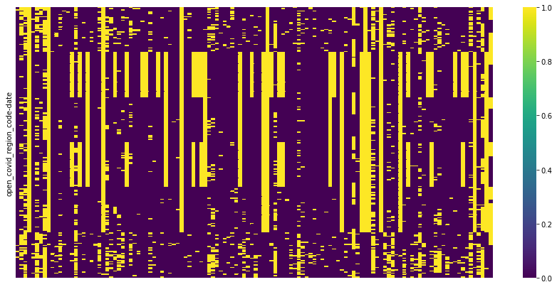

```python
plt.figure(figsize = (15,7))
sns.heatmap(data = left_df.isnull(),xticklabels = False, yticklabels = False, cmap = 'viridis')
# It is very clear that for a few range of columns, a huge chunk of data is missing. So those features are removed.
```

```python
# With features missing atleast 25% of its data, they are straight away removed.

# Removed 42 more features (from 122 to 80) excluding the hospitalized_new target value
target = left_df['hospitalized_new']
left_df = left_df[left_df.drop('hospitalized_new',axis=1).columns[left_df.drop('hospitalized_new',axis=1).isnull().mean() < 0.25]]
left_df = pd.concat([left_df,target],axis=1)
left_df.shape
```

```
(234, 80)
```

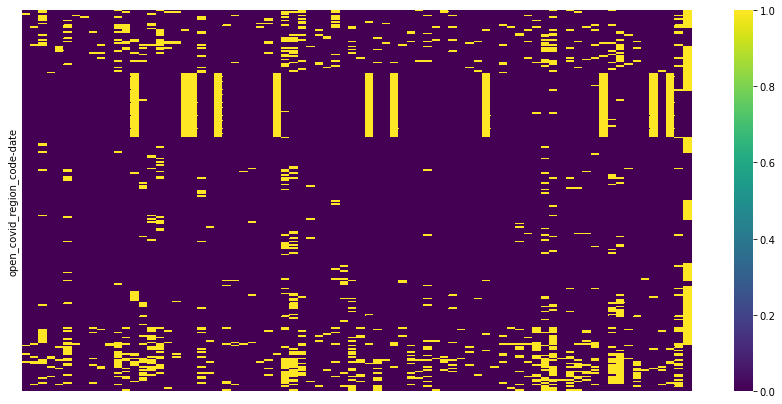

```python
plt.figure(figsize = (15,7))
sns.heatmap(data = left_df.isnull(),xticklabels = False, yticklabels = False, cmap = 'viridis')
```

Random imputations are not thought to be best, because the authors of this project have are not physicians and they cannot draw conclusions from the features/symptoms. The authors do not know if "mean imputations are best" or "weighted mean imputations are best" or "random imputations with probability disributions are best". It's best to correlate and find impute values on those correlated features.

```python
left_df.head()
```

| open_covid_region_code | date | symptom:Adrenal crisis | symptom:Amenorrhea | symptom:Anosmia | symptom:Asphyxia | symptom:Atheroma | symptom:Auditory hallucination | symptom:Balance disorder | symptom:Beau's lines | symptom:Cataplexy | symptom:Chorea | symptom:Cleft lip and cleft palate | symptom:Clouding of consciousness | symptom:Crepitus | symptom:Croup | symptom:Cyanosis | symptom:Depersonalization | symptom:Dysautonomia | symptom:Dysgeusia | symptom:Dyspareunia | symptom:Dystonia | symptom:Dysuria | symptom:Epiphora | symptom:Esophagitis | symptom:Eye pain | symptom:Facial swelling | symptom:Fibrocystic breast changes | symptom:Focal seizure | symptom:Gastroparesis | … |
| --- | --- | --- | --- | --- | --- | --- | --- | --- | --- | --- | --- | --- | --- | --- | --- | --- | --- | --- | --- | --- | --- | --- | --- | --- | --- | --- | --- | --- | --- | --- |
| US-AK | 2020-01-06 | 12.69 | 12.29 | NaN | 10.31 | 11.10 | 8.92 | 11.10 | 7.93 | 12.29 | 12.10 | 18.05 | NaN | 12.49 | 25.78 | 10.51 | 12.10 | NaN | 7.93 | 7.93 | 14.87 | 15.47 | 8.13 | 9.12 | 15.47 | 8.72 | 17.65 | 9.52 | 11.50 | … |
|  | 2020-01-13 | 9.56 | 12.62 | NaN | 13.20 | 13.20 | 8.61 | 10.90 | 11.86 | 14.92 | 11.47 | 34.81 | 9.95 | NaN | 25.05 | 11.86 | 7.65 | 11.09 | NaN | NaN | 17.79 | 13.01 | 12.81 | 10.71 | 11.67 | 11.67 | 10.71 | 11.67 | 16.64 | … |
|  | 2020-01-20 | NaN | 14.17 | 7.36 | 14.90 | 10.49 | 8.28 | 11.78 | 11.96 | 11.04 | 11.59 | 19.14 | 8.83 | 10.49 | 29.99 | 7.73 | NaN | 10.12 | 11.04 | 8.46 | 17.85 | 15.82 | 9.75 | 9.20 | 15.27 | 10.86 | 14.54 | 16.38 | 13.25 | … |
|  | 2020-01-27 | 15.31 | 15.67 | NaN | 12.03 | 11.84 | 13.12 | NaN | 12.03 | 13.85 | 12.94 | 15.49 | 9.84 | 12.39 | 29.52 | 9.84 | 8.20 | 8.56 | 8.93 | 8.02 | 13.67 | 11.30 | 9.66 | 10.57 | 12.57 | 11.48 | NaN | 14.94 | 11.84 | … |
|  | 2020-02-03 | 8.81 | 13.87 | NaN | 14.24 | 9.75 | 8.81 | 13.12 | NaN | 14.24 | 15.37 | 13.12 | NaN | 9.93 | 39.36 | 10.87 | 9.37 | 8.62 | 9.93 | 11.06 | 20.43 | 16.87 | NaN | 12.56 | 11.62 | 11.24 | 9.18 | 8.43 | 8.43 | … |

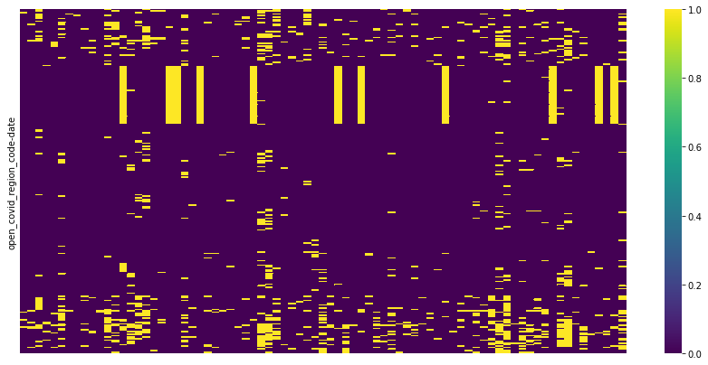

```python
# Now let's build a df just for PCA!
pca_df = left_df.drop('hospitalized_new',axis=1)
plt.figure(figsize = (15,7))
sns.heatmap(data = pca_df.isnull(),xticklabels = False, yticklabels = False, cmap = 'viridis')
```

```python
stateindex = pca_df.index.levels[0]
pca_df.loc[stateindex[0]].median()
```

```
symptom:Adrenal crisis                10.150
symptom:Amenorrhea                    10.430
symptom:Anosmia                       9.695
symptom:Asphyxia                      12.450
symptom:Atheroma                      10.790
symptom:Auditory hallucination        7.885
symptom:Balance disorder              11.385
symptom:Beau's lines                  10.365
symptom:Cataplexy                     9.580
symptom:Chorea                        10.365
symptom:Cleft lip and cleft palate    11.590
symptom:Clouding of consciousness     9.250
symptom:Crepitus                      8.980
symptom:Croup                         12.220
symptom:Cyanosis                      9.940
symptom:Depersonalization             9.400
symptom:Dysautonomia                  8.560
symptom:Dysgeusia                     9.230
symptom:Dyspareunia                   9.030
symptom:Dystonia                      13.665
symptom:Dysuria                       12.160
symptom:Epiphora                      8.130
symptom:Esophagitis                   9.750
symptom:Eye pain                      11.670
symptom:Facial swelling               10.495
symptom:Fibrocystic breast changes    9.180
symptom:Focal seizure                 9.640
symptom:Gastroparesis                 10.690
symptom:Gingival recession            10.870
symptom:Globus pharyngis              9.080
symptom:Grandiosity                   12.780
symptom:Hemolysis                     7.935
symptom:Hemoptysis                    7.670
symptom:Hepatic encephalopathy        8.410
symptom:Hepatotoxicity                9.585
symptom:Hydrocephalus                 9.840
symptom:Hypercalcaemia                9.315
symptom:Hypercapnia                   8.155
symptom:Hyperemesis gravidarum        10.580
symptom:Hypersomnia                   8.890
```

[output cut: 25 more lines]

```
symptom:Rheum                         9.150
symptom:Rumination                    9.085
symptom:Sensitivity to sound          9.970
symptom:Spasticity                    8.930
symptom:Splenomegaly                  10.810
symptom:Stomach rumble                8.335
symptom:Stridor                       10.455
symptom:Subdural hematoma             9.640
symptom:Tachypnea                     9.460
symptom:Tenderness                    11.240
symptom:Thyroid nodule                12.900
symptom:Trichoptilosis                10.550
symptom:Urethritis                    11.910
symptom:Ventricular fibrillation      8.620
dtype: float64
```

```python
# Now we need to combine values across regions! We need to normalize this by a baseline value
# An easy way to do this is to divide by the median of each symptom for every region
# This way we test variability

stateindex = pca_df.index.levels[0]
frames = []

for i in range(len(stateindex)):

    try:
        medians = pca_df.loc[stateindex[i]].median()
        framesdf = pca_df.loc[stateindex[i]]/medians
        framesdf['open_covid_region_code'] = stateindex[i]
        framesdf = framesdf.set_index(['open_covid_region_code',framesdf.index])
        frames.append(framesdf)

    except:
        pass

pca_df = pd.concat(frames)
```